# 3

### Modelių palyginimas ir prognozė.

1. Suskaičiuokite modelio fit RMSE (Root Mean Squere Error), kuris apibrėžiamas taip
   $$RMSE = \sqrt{\frac{1}{n} \sum_{i=1}^n \varepsilon_t^2}.$$

RMSE suskaičiuokite abiem duomenų masyvams trainSet ir testSet. Rezultatus sudėkite į lentelę. Palyginkite rezultatus ir padarykite išvadas.

```r
RMSE = function(duomenys){
  n = length(duomenys$kaina)
  return(sqrt(mean(duomenys$kaina - predict(fit, duomenys))^2))
}
RMSE(trainSet)
```

```
## [1] 4.625706e-14
```

```r
RMSE(testSet)
```

```
## [1] 9.126032
```

Išvada tokia, kad modelis tinka tik tai imčiai, su kuria jis sukurtas, tačiau kitiem duomenim ji, deja, netinka.

2. Išbrėžkite sklaidos diagramą, kurioje $x$ ašyje būtų fit modelio testSet prognozė, o $y$ ašyje faktinės testSet kainų reikšmės. Ant šios sklaidos diagramos išbrėžkite dvi linijas, kurios žymėtų prognozės pasikliautinus intervalus (pasikliovimo lygmuo 90 proc.).

```r
quantile(predict(fit, testSet), probs = c(0.05, 0.95))
```

[output not shown]

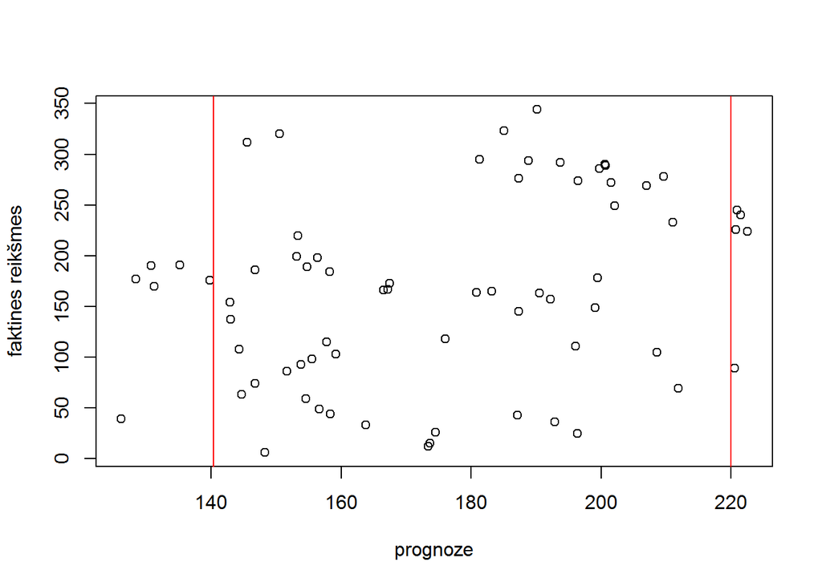

```r
plot(predict(fit, testSet), testSet$kaina, xlab = "prognozė", ylab = "faktinės reikšmės")
abline(v = 140.3756, col = 2)
abline(v = 220.0027, col = 2)
```

3. Kiek procentų prognozuotų reikšmių nepateko į pasikliautinus intervalus?

```r
(sum(predict(fit, testSet) < 140.3756 | predict(fit, testSet) > 220.0027)) / length(predict(fit, testSet)) * 100
```

```
## [1] 15.94203
```